# Essercitazione 5: Integrali (10/12/2025)

## Esercizio 5.1

Studiare la funzione $$ f(z) = \frac{z^3}{2z^4 + 1} $$ e calcolare l’integrale $$ \int_C f(z)\,dz, \qquad C = \{z \in \mathbb{C} : |z| = 1\}. $$

## Soluzione Esercizio 5.1

### 1. Studio della funzione

Il numeratore (e quindi la funzione) ha un **zero triplo** in $z = 0$

Gli zeri del denominatore sono le **singolarità** della funzione, cioè le soluzioni di $$ 2z^4 + 1 = 0 \quad \Longleftrightarrow \quad z^4 = -\frac{1}{2}. $$

Scriviamo $$ -\frac{1}{2} = \frac{1}{2} e^{i\pi}, $$ quindi le soluzioni sono $$ z_k = 2^{-\frac{1}{4}} e^{i\left(\frac{\pi}{4} + k\frac{\pi}{2}\right)}, \qquad k = 0,1,2,3. $$

Osserviamo che $$ |z_k| = 2^{-\frac{1}{4}} < 1, $$ quindi **tutti e quattro i poli** di (f) stanno **all’interno della circonferenza** (|z|=1).

Poiché il denominatore ha zeri semplici (le radici di un polinomio senza radici multiple) e il numeratore è olomorfo, le singolarità di (f) sono **poli semplici**.

### Comportamento all'infinito

Per studiare il comportamento di
$$ f(z) = \frac{z^3}{2z^4 + 1} $$ all’infinito, consideriamo due metodi diversi.

## ** Analisi dei gradi e fattorizzazione**

Confrontiamo i gradi di numeratore e denominatore:

- $\deg(z^3) = 3$
- $\deg(2z^4 + 1) = 4$

Poiché il grado del denominatore è maggiore, $$ f(z) \longrightarrow 0 \qquad \text{per } |z|\to\infty. $$

Riscrivendo: $$ f(z) = \frac{z^3}{2z^4 + 1} = \frac{1}{z} \cdot \frac{1}{2 + \frac{1}{z^4}} \sim \frac{1}{2z}, \qquad |z|\to\infty. $$

Quindi $f$ si comporta come $1/(2z)$, che ha **uno zero semplice in $\infty$**.  
Di conseguenza:

$$ \infty \quad \text{è una singolarità eliminabile (zero di ordine 1).} $$

## 📘 Singolarità all’Infinito

### 🧭 Regola fondamentale

Per studiare la singolarità in $\infty$ si considera $$ g(w) = f\!\left(\frac{1}{w}\right). $$

Vale la caratterizzazione: $$ f(z) \text{ ha una singolarità essenziale in } \infty \iff g(w) \text{ ha una singolarità essenziale in } 0. $$

## 🧪 Criterio pratico

Osservare lo sviluppo di Laurent di $g(w)=f(1/w)$ in $w=0$:

- **Infiniti termini con potenze negative** $\to $ Singolarità essenziale
- **Numero finito di termini negativi** $\rightarrow$ Polo di ordine finito
- **Nessun termine negativo** $\rightarrow$ Singolarità eliminabile

## 🟦 Classificazione rapida per tipo di funzione

| Tipo di funzione | Comportamento in $\infty$ | Tipo di singolarità |
| --- | --- | --- |
| Razionali $p(z)/q(z)$ | Serie finita in $1/z$ | ❌ Mai essenziale |
| Polinomi | $z^n \to \infty$ | Polo (ordine $n$) |
| Esponenziali $e^{az}$ | $e^{a/w}$ ⇒ infiniti termini | ✔ Essenziale |
| Trigonometriche $\sin z, \cos z$ | $\sin(1/w), \cos(1/w)$ serie infinite | ✔ Essenziale |
| Iperboliche $\sinh z, \cosh z$ | Come le trigonometriche | ✔ Essenziale |
| Logaritmo $\log z$ | $-\log w $ (non meromorfa) | Singolare ma non essenziale |
| Composizioni trascendenti | Espansioni infinite | ✔ Probabile essenziale |

## ⭐ Esempi tipici

[output not shown]

## 🧩 Regola ultra-rapida

- $ f(z) \text{ è razionale} \;\Longrightarrow\; \text{mai essenziale in }\infty.$
- $ f(z) \text{ contiene } e^z, \sin z, \cos z, \sinh z, \cosh z \;\Longrightarrow\; \text{quasi certamente essenziale.}$
- Lo sviluppo in $1/z$ ha infiniti termini negativi $\Longrightarrow$ essenziale.
- Se $ f(z) $ oscilla o cresce in modo incontrollato per $z\to\infty$ $\Longrightarrow$ essenziale.

## 🧠 Riassunto

$$ \boxed{ \text{La singolarità di } f \text{ in } \infty \text{ è essenziale} \;\Longleftrightarrow\; f(1/w) \text{ ha infiniti termini negativi nello sviluppo di Laurent in } w=0. } $$

### 2. Calcolo dei residui

Scriviamo $$ f(z) = \frac{p(z)}{q(z)}, \qquad p(z) = z^3, \quad q(z) = 2z^4 + 1. $$

Per un polo semplice $z_0$ (cioè $q(z_0) = 0$ e $q'(z_0) \neq 0$), il residuo è $$ \operatorname{Res}(f, z_0) = \frac{p(z_0)}{q'(z_0)}. $$

Calcoliamo la derivata del denominatore: $$ q'(z) = \frac{d}{dz}(2z^4 + 1) = 8z^3. $$

Per ciascun polo $z_k$ si ha quindi $$ \operatorname{Res}(f, z_k) = \frac{p(z_k)}{q'(z_k)} = \frac{z_k^3}{8 z_k^3} = \frac{1}{8}. $$

Tutti e quattro i poli hanno dunque lo **stesso residuo**, pari a $1/8$. La somma dei residui all’interno di $C$ è $$ \sum_{k=0}^3 \operatorname{Res}(f, z_k) = 4 \cdot \frac{1}{8} = \frac{1}{2}. $$

### 3. Applicazione del teorema dei residui

La curva $C = \{ z : |z| = 1 \}$ è orientata positivamente (verso antiorario). Per il teorema dei residui vale $$ \int_C f(z)\,dz = 2\pi i \sum_{\text{poli dentro } C} \operatorname{Res}(f,z_k). $$

Nel nostro caso, $$ \sum_{\text{poli dentro } C} \operatorname{Res}(f,z_k) = \frac{1}{2}, $$ quindi $$ \int_C \frac{z^3}{2z^4 + 1}\,dz = 2\pi i \cdot \frac{1}{2} = \pi i. $$

**Risultato finale:** $$ \boxed{\displaystyle \int_C \frac{z^3}{2z^4 + 1}\,dz = \pi i.} $$

## Soluzione con Python (Sympy / mpmath)

```
Zeri di f(z):
[0]

 Poli di f(z):
⎡  4 ___   4 ___      4 ___   4 ___    4 ___   4 ___    4 ___   4 ___  ⎤
⎢  ╲╱ 2    ╲╱ 2 ⋅ⅈ    ╲╱ 2    ╲╱ 2 ⋅ⅈ  ╲╱ 2    ╲╱ 2 ⋅ⅈ  ╲╱ 2    ╲╱ 2 ⋅ⅈ⎥
⎢- ───── - ───────, - ───── + ───────, ───── - ───────, ───── + ───────⎥
⎣    2        2         2        2       2        2       2        2   ⎦
```

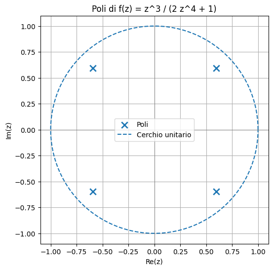

```python
import sympy as sp
import numpy as np
import matplotlib.pyplot as plt

# ----------------------------------------
# 1. Definizione della funzione f(z)
# ----------------------------------------
z = sp.symbols('z')
f = z**3 / (2*z**4 + 1)

# ----------------------------------------
# 2. Zeri e poli con SymPy
# ----------------------------------------

# Zeri: soluzioni del numeratore = 0
num = sp.numer(f)
zeri = sp.solve(sp.Eq(num, 0), z)

# Poli: soluzioni del denominatore = 0
den = sp.denom(f)
poli = sp.solve(sp.Eq(den, 0), z)

print("Zeri di f(z):")
#print(zeri)
sp.pprint(zeri)
print("\n Poli di f(z):")
sp.pprint(poli)
#print(poli)

# ----------------------------------------
# 3. Conversione in numeri complessi per il grafico
# ----------------------------------------
# Zeri (complessi "standard" di Python).
zeri_c = [complex(sp.N(z0)) for z0 in zeri]  # OBS si puo anche fare con numpy senza usare sympy
# Poli
poli_c = [complex(sp.N(p0)) for p0 in poli]

# Coordinate (Re, Im) per zeri e poli
zeri_x = [z0.real for z0 in zeri_c]
zeri_y = [z0.imag for z0 in zeri_c]

poli_x = [p0.real for p0 in poli_c]
poli_y = [p0.imag for p0 in poli_c]

# ----------------------------------------
# 4. Grafico nel piano complesso
# ----------------------------------------
plt.figure(figsize=(6, 6))

# Poli: in rosso (per esempio crocette)
plt.scatter(poli_x, poli_y, marker='x', s=80, label='Poli', linewidths=2)

# Cerchio unitario (utile per l'esercizio 1)
theta = np.linspace(0, 2*np.pi, 400)
plt.plot(np.cos(theta), np.sin(theta), linestyle='--', label='Cerchio unitario')

# Assi e aspetto
plt.axhline(0, color='gray', linewidth=0.7)
plt.axvline(0, color='gray', linewidth=0.7)
plt.gca().set_aspect('equal', 'box')
plt.xlabel('Re(z)')
plt.ylabel('Im(z)')
plt.title('Poli di f(z) = z^3 / (2 z^4 + 1)')
plt.legend()
plt.grid(True)
plt.show()
```

Calcolo dei residui

```python
# ------------------------------
# 3. Calcolo dei residui in ciascun polo
# ------------------------------
print("Residui nei poli:\n")

residui = []
for p in poli:
    R = sp.residue(f, z, p)
    residui.append((p, sp.simplify(R)))
    print(f"Residuo in z0 = {p}:")
    sp.pprint(sp.simplify(R))
    print()

# ------------------------------
# 4. Somma dei residui (utile per controlli)
# ------------------------------
somma_res = sum(R for _, R in residui)
print("Somma totale dei residui:")
sp.pprint(sp.simplify(somma_res))
```

```
Residui nei poli:

Residuo in z0 = -2**(1/4)/2 - 2**(1/4)*I/2:
1/8

Residuo in z0 = -2**(1/4)/2 + 2**(1/4)*I/2:
1/8

Residuo in z0 = 2**(1/4)/2 - 2**(1/4)*I/2:
1/8

Residuo in z0 = 2**(1/4)/2 + 2**(1/4)*I/2:
1/8

Somma totale dei residui:
1/2
```

Residuo all'infinito

```python
# Metodo 1: definizione esplicita con w = 1/z

w = sp.symbols('w')
g = (1/w**2) * f.subs(z, 1/w)   # g(w) = (1/w^2) * f(1/w)

res_w0 = sp.residue(g, w, 0)    # Res g(w) in w=0
res_infty = -res_w0             # Res_inf f = - Res_0 g

print("Residuo in w=0 di g(w) =", sp.simplify(res_w0))
print("Residuo all'infinito di f =", sp.simplify(res_infty))
```

```
Residuo in w=0 di g(w) = 1/2
Residuo all'infinito di f = -1/2
```

### NB: ripetiamo l'essercizio con Numpy

```python
import numpy as np

# Polinomio del denominador: q(z) = 2 z^4 + 0 z^3 + 0 z^2 + 0 z + 1
q_coeffs = [2, 0, 0, 0, 1]
poles = np.roots(q_coeffs)

# Polinomio del numerador: p(z) = z^3 = 1 z^3 + 0 z^2 + 0 z + 0
p_coeffs = [1, 0, 0, 0]
zeros = np.roots(p_coeffs)

print("Poli (numerico):", poles)
print("Zeri (numerico):", zeros)
```

```
Poli (numerico): [-0.59460356+0.59460356j -0.59460356-0.59460356j  0.59460356+0.59460356j
  0.59460356-0.59460356j]
Zeri (numerico): [0. 0. 0.]
```

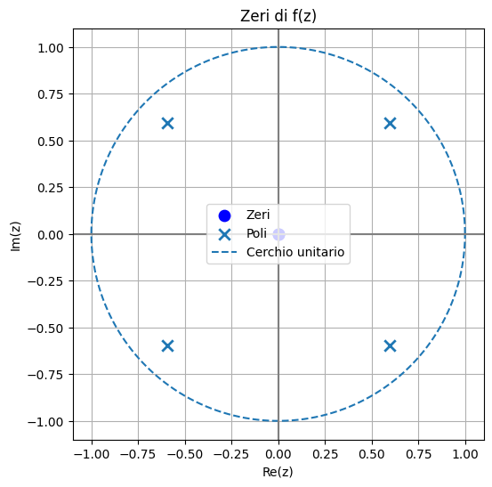

```python
#zeros = np.roots(p_coeffs)
zx = zeros.real
zy = zeros.imag

#poles = np.roots(q_coeffs)
px = poles.real
py = poles.imag

plt.figure(figsize=(6,6))

plt.scatter(zx, zy, color="blue", s=80, label="Zeri")
plt.scatter(px, py, marker='x', s=80, label='Poli', linewidths=2)
theta = np.linspace(0, 2*np.pi, 400)
plt.plot(np.cos(theta), np.sin(theta), linestyle='--', label='Cerchio unitario')

plt.axhline(0, color="gray")
plt.axvline(0, color="gray")

plt.gca().set_aspect("equal")
plt.xlabel("Re(z)")
plt.ylabel("Im(z)")
plt.title("Zeri di f(z)")
plt.grid(True)
plt.legend()
plt.show()
```

## Esercizio 5.2

Calcolare l’integrale reale improprio $$ I = \int_{-\infty}^{+\infty} \frac{dx}{1 + x^{2n}}, \qquad n \in \mathbb{Z}_{>0}. $$

### 1. Osservazioni preliminari

Consideriamo l’integrale $$ I = \int_{-\infty}^{+\infty} \frac{dx}{1 + x^{2n}}. $$

- Per $|x|\to\infty$ si ha $$ \frac{1}{1 + x^{2n}} \sim \frac{1}{x^{2n}}, $$ quindi l’integrale **converge** per ogni $n \ge 1$.

Useremo il metodo dei residui per calcolare l’integrale $$ \int_{-\infty}^{+\infty} \frac{dx}{1 + x^{2n}}, $$ e poi, se necessario, dividiamo per $2$ per ottenere quello su $[0,+\infty)$.

### 2. Estensione complessa e scelta del contorno

Consideriamo la funzione complessa $$ f(z) = \frac{1}{1 + z^{2n}}. $$

Le singolarità di $f$ sono date dalle soluzioni di $$ 1 + z^{2n} = 0 \;\Longleftrightarrow\; z^{2n} = -1 = e^{i\pi}. $$

Le $2n$ radici sono $$ z_k = e^{i\left(\frac{\pi}{2n} + k\frac{\pi}{n}\right)}, \qquad k = 0,1,\dots,2n-1. $$

Sono tutti punti **sulla circonferenza unitaria** $|z|=1$ e sono tutti **poli semplici**, perché il denominatore ha zeri semplici.

Per applicare il teorema dei residui all’integrale reale, scegliamo il solito **contorno semicircolare nel semipiano superiore**:

- asse reale da $-R$ a $R$,
- semicirconferenza di raggio $R$ nel semipiano superiore.

Al limite $R \to +\infty$, il contributo dell’arco tende a $0$ (per $n \ge 1$), e l’integrale lungo l’asse reale tende a $$ \int_{-\infty}^{+\infty} \frac{dx}{1 + x^{2n}}. $$

### 3. Poli nel semipiano superiore e calcolo dei residui

Le radici di $$ 1 + z^{2n} = 0 $$ nel semipiano superiore sono quelle con $$ 0 < \arg(z_k) < \pi. $$

Corrispondono a $$ z_k = e^{i\left(\frac{\pi}{2n} + k\frac{\pi}{n}\right)}, \qquad k = 0,1,\dots,n-1. $$

Per calcolare i residui, scriviamo $$ f(z) = \frac{1}{1 + z^{2n}} = \frac{1}{g(z)}, \qquad g(z) = 1 + z^{2n}. $$

Allora $$ g'(z) = 2n\,z^{2n-1}. $$

Se $z_k$ è una radice semplice di $g(z)$, il residuo di $f$ in $z_k$ è $$ \operatorname{Res}\bigl(f,z_k\bigr) = \frac{1}{g'(z_k)} = \frac{1}{2n\,z_k^{2n-1}}. $$

Dunque, la somma dei residui nei poli del **semipiano superiore** è $$ \sum_{k=0}^{n-1} \operatorname{Res}\bigl(f,z_k\bigr) = \sum_{k=0}^{n-1} \frac{1}{2n\,z_k^{2n-1}}. $$

### 4. Somma esplicita dei residui

Ricordiamo che $$ z_k = e^{i\left(\frac{\pi}{2n} + k\frac{\pi}{n}\right)}. $$

Allora $$ z_k^{2n} = -1, \qquad z_k^{2n-1} = \frac{z_k^{2n}}{z_k} = \frac{-1}{z_k} = -\,z_k^{-1}. $$

Quindi $$ \frac{1}{z_k^{2n-1}} = -\,z_k. $$

Pertanto $$ \operatorname{Res}\bigl(f,z_k\bigr) = \frac{1}{2n\,z_k^{2n-1}} = \frac{-z_k}{2n}. $$

La somma dei residui nel semipiano superiore è $$ \sum_{k=0}^{n-1} \operatorname{Res}\bigl(f,z_k\bigr) = -\frac{1}{2n} \sum_{k=0}^{n-1} z_k. $$

Ma $$ z_k = e^{i\left(\frac{\pi}{2n} + k\frac{\pi}{n}\right)} = e^{i\frac{\pi}{2n}} \cdot e^{ik\frac{\pi}{n}}. $$

Quindi $$ \sum_{k=0}^{n-1} z_k = e^{i\frac{\pi}{2n}} \sum_{k=0}^{n-1} e^{ik\frac{\pi}{n}}, $$ che è una somma di progressione geometrica: $$ \sum_{k=0}^{n-1} e^{ik\theta} = \frac{1 - e^{in\theta}}{1 - e^{i\theta}}, \qquad \theta = \frac{\pi}{n}. $$

Allora $$ \sum_{k=0}^{n-1} e^{ik\frac{\pi}{n}} = \frac{1 - e^{i n\cdot \frac{\pi}{n}}}{1 - e^{i\frac{\pi}{n}}} = \frac{1 - e^{i\pi}}{1 - e^{i\frac{\pi}{n}}} = \frac{1 - (-1)}{1 - e^{i\frac{\pi}{n}}} = \frac{2}{1 - e^{i\frac{\pi}{n}}}. $$

Dunque $$ \sum_{k=0}^{n-1} z_k = e^{i\frac{\pi}{2n}} \cdot \frac{2}{1 - e^{i\frac{\pi}{n}}}. $$

### 5. Teorema dei residui e semplificazione

Il teorema dei residui sul contorno semicircolare nel semipiano superiore dà $$ \int_{-\infty}^{+\infty} \frac{dx}{1 + x^{2n}} = 2\pi i \sum_{\substack{\text{poli in} \\ \text{semipiano superiore}}} \operatorname{Res}(f,z_k). $$

Abbiamo trovato $$ \sum_{k=0}^{n-1} \operatorname{Res}(f,z_k) = -\frac{1}{2n} \sum_{k=0}^{n-1} z_k = -\frac{1}{2n} \, e^{i\frac{\pi}{2n}} \cdot \frac{2}{1 - e^{i\frac{\pi}{n}}} = -\frac{1}{n} \, \frac{e^{i\frac{\pi}{2n}}}{1 - e^{i\frac{\pi}{n}}}. $$

Allora $$ \int_{-\infty}^{+\infty} \frac{dx}{1 + x^{2n}} = 2\pi i \left( -\frac{1}{n} \cdot \frac{e^{i\frac{\pi}{2n}}}{1 - e^{i\frac{\pi}{n}}} \right) = -\,\frac{2\pi i}{n} \cdot \frac{e^{i\frac{\pi}{2n}}}{1 - e^{i\frac{\pi}{n}}}. $$

Ora semplifichiamo il fattore complesso. Scriviamo $$ 1 - e^{i\frac{\pi}{n}} = e^{i\frac{\pi}{2n}}\left( e^{-i\frac{\pi}{2n}} - e^{i\frac{\pi}{2n}} \right) = e^{i\frac{\pi}{2n}} \bigl(-2i \sin(\tfrac{\pi}{2n})\bigr). $$

Quindi $$ \frac{e^{i\frac{\pi}{2n}}}{1 - e^{i\frac{\pi}{n}}} = \frac{e^{i\frac{\pi}{2n}}}{e^{i\frac{\pi}{2n}} \cdot (-2i \sin(\tfrac{\pi}{2n}))} = \frac{1}{-2i \sin(\tfrac{\pi}{2n})} = \frac{i}{2 \sin(\tfrac{\pi}{2n})}. $$

Sostituendo: $$ \int_{-\infty}^{+\infty} \frac{dx}{1 + x^{2n}} = -\,\frac{2\pi i}{n} \cdot \frac{i}{2 \sin(\tfrac{\pi}{2n})} = \frac{\pi}{n} \cdot \frac{1}{\sin\left(\tfrac{\pi}{2n}\right)}. $$

Otteniamo quindi la formula finale: $$ \boxed{ \displaystyle \int_{-\infty}^{+\infty} \frac{dx}{1 + x^{2n}} = \frac{\pi}{n \,\sin\!\left(\frac{\pi}{2n}\right)} } \qquad (n \in \mathbb{Z}_{>0}). $$

In particolare:

- per $n=1$, $$ \int_{-\infty}^{+\infty} \frac{dx}{1 + x^{2}} = \frac{\pi}{1\cdot \sin(\tfrac{\pi}{2})} = \pi $$
- per $n=2$, $$ \int_{-\infty}^{+\infty} \frac{dx}{1 + x^{4}} = \frac{\pi}{2\sin(\tfrac{\pi}{4})} = \frac{\pi}{2} \cdot \frac{1}{\tfrac{\sqrt{2}}{2}} = \frac{\pi}{\sqrt{2}} $$

### Risolviamo con python (per alcuni valori di n)

```python
import sympy as sp

sp.init_printing()

# Variabile reale per l'integrazione
x = sp.symbols('x', real=True)

def integrale_residui(n_val):
    """
    Calcola I_n = ∫_{-∞}^{+∞} dx / (1 + x^{2n})
    usando il teorema dei residui con SymPy,
    per un dato intero n_val >= 1.
    """
    n = sp.Integer(n_val)
    z = sp.symbols('z')

    # Funzione complessa
    f = 1 / (1 + z**(2*n))

    # Poli: radici di 1 + z^{2n} = 0
    poli = sp.solve(sp.Eq(1 + z**(2*n), 0), z)

    # Filtriamo solo i poli nel semipiano superiore (Im(z) > 0)
    poli_sup = [p for p in poli if sp.im(p) > 0]

    # Somma dei residui nei poli del semipiano superiore
    S = sum(sp.residue(f, z, p) for p in poli_sup)

    # Integrale (asse reale) dato dal contorno semicircolare
    I = 2 * sp.pi * sp.I * S
    return sp.simplify(I)

def formula_teorica(n_val):
    n = sp.Integer(n_val)
    return sp.simplify(sp.pi / (n * sp.sin(sp.pi / (2*n))))

# Proviamo per alcuni valori di n
for n_val in [1, 2, 3, 4]:
    I_res = integrale_residui(n_val)
    I_th = formula_teorica(n_val)

    print(f"n = {n_val}")
    print("  Integrale via residui:   ")
    sp.pprint(I_res)
    print("  Formula teorica:         ")
    sp.pprint(I_th)
    print("  Differenza (res - teo):  ")
    sp.pprint(sp.simplify(I_res - I_th))
    print("-" * 40)
```

```
n = 1
  Integrale via residui:
π
  Formula teorica:
π
  Differenza (res - teo):
0
----------------------------------------
n = 2
  Integrale via residui:
√2⋅π
────
 2
  Formula teorica:
√2⋅π
────
 2
  Differenza (res - teo):
0
----------------------------------------
n = 3
  Integrale via residui:
2⋅π
───
 3
  Formula teorica:
2⋅π
───
 3
  Differenza (res - teo):
0
----------------------------------------
n = 4
  Integrale via residui:
       π⋅(1 + ⅈ + √2⋅ⅈ)
─────────────────────────────
  ⎛  ________       ________⎞
2⋅⎝╲╱ 2 - √2  + ⅈ⋅╲╱ √2 + 2 ⎠
  Formula teorica:
     π
────────────
    ________
2⋅╲╱ 2 - √2
  Differenza (res - teo):
  ⎛    ________     ________     __________⎞
π⋅⎝- ╲╱ √2 + 2  + ╲╱ 2 - √2  + ╲╱ 4 - 2⋅√2 ⎠
────────────────────────────────────────────
     ⎛  ________   ________             ⎞
   2⋅⎝╲╱ 2 - √2 ⋅╲╱ √2 + 2  - 2⋅ⅈ + √2⋅ⅈ⎠
----------------------------------------
```

Integrale numerica (Senza residui)

```python
import mpmath as mp

mp.mp.dps = 40  # cifre decimali di precisione

def integrale_numerico(n):
    """
    Calcola numericamente I_n = ∫_{-∞}^{+∞} dx / (1 + x^{2n})
    usando mpmath.quad.
    """
    f = lambda x: 1 / (1 + x**(2*n))
    # integriamo su (-∞, +∞) spezzando in due per sicurezza
    return mp.quad(f, [-mp.inf, 0, mp.inf])

def formula_teorica_num(n):
    return mp.pi / (n * mp.sin(mp.pi / (2*n)))

for n in [1, 2, 3, 4, 5]:
    I_num = integrale_numerico(n)
    I_th = formula_teorica_num(n)
    diff = I_num - I_th

    print(f"n = {n}")
    print("  Integrale numerico  ≈", I_num)
    print("  Formula analitica    ≈", I_th)
    print("  Differenza          ≈", diff)
    print()
```

```
n = 1
  Integrale numerico  ≈ 3.141592653589793238462643383279502884197
  Formula analitica    ≈ 3.141592653589793238462643383279502884197
  Differenza          ≈ 0.0

n = 2
  Integrale numerico  ≈ 2.221441469079183123507940495030346849307
  Formula analitica    ≈ 2.221441469079183123507940495030346849307
  Differenza          ≈ -4.591774807899560578002877098524397178979e-41

n = 3
  Integrale numerico  ≈ 2.094395102393195492308428922186335256131
  Formula analitica    ≈ 2.094395102393195492308428922186335256131
  Differenza          ≈ 0.0

n = 4
  Integrale numerico  ≈ 2.052344305954061777742935561745663949959
  Formula analitica    ≈ 2.052344305954061777742935561745663949959
  Differenza          ≈ 0.0

n = 5
  Integrale numerico  ≈ 2.033281476926103926323803605296879536733
  Formula analitica    ≈ 2.033281476926103926323803605296879536733
  Differenza          ≈ 0.0
```

** Integrale numerica con sympy **

```python
import sympy as sp

sp.init_printing()
x = sp.symbols('x', real=True)

for n_val in [1, 2, 3, 4]:
    n = sp.Integer(n_val)
    f = 1 / (1 + x**(2*n))

    print(f"n = {n_val}")
    try:
        I_sym = sp.integrate(f, (x, -sp.oo, sp.oo))
        print("  Integrale simbolico diretto:")
        sp.pprint(I_sym)
        print("  Formula analitica:")
        sp.pprint(sp.pi / (n * sp.sin(sp.pi / (2*n))))
        print("  Differenza:")
        sp.pprint(sp.simplify(I_sym - sp.pi / (n * sp.sin(sp.pi / (2*n)))))
    except Exception as e:
        print("  SymPy non riesce a integrare simbolicamente:")
        print(" ", e)
    print("-" * 40)
```

```
n = 1
  Integrale simbolico diretto:
π
  Formula analitica:
π
  Differenza:
0
----------------------------------------
n = 2
  Integrale simbolico diretto:
√2⋅π
────
 2
  Formula analitica:
√2⋅π
────
 2
  Differenza:
0
----------------------------------------
n = 3
  Integrale simbolico diretto:
2⋅π
───
 3
  Formula analitica:
2⋅π
───
 3
  Differenza:
0
----------------------------------------
n = 4
  Integrale simbolico diretto:
     π
────────────
    ________
2⋅╲╱ 2 - √2
  Formula analitica:
      π
──────────────
      ________
     ╱ 1   √2
4⋅  ╱  ─ - ──
  ╲╱   2   4
  Differenza:
0
----------------------------------------
```

### Plot dei residui

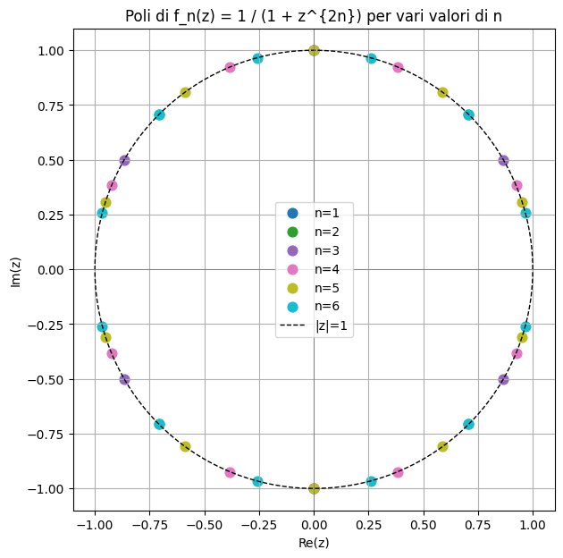

```python
import numpy as np
import matplotlib.pyplot as plt

# -----------------------------------------------
# Parametri: scegli i valori di n che vuoi tracciare
# -----------------------------------------------
n_values = [1, 2, 3, 4, 5, 6]

# Colori per distinguerli
colors = plt.cm.tab10(np.linspace(0, 1, len(n_values)))

plt.figure(figsize=(7, 7))

for idx, n in enumerate(n_values):

    # Polinomio del denominatore: 1 + z^(2n)
    # I coefficienti vanno dal grado più alto al più basso:
    # z^(2n) + 1 → [1, 0, 0, ..., 0, 1]
    coeffs = [0] * (2*n + 1)
    coeffs[0] = 1     # coefficiente di z^(2n)
    coeffs[-1] = 1    # coefficiente di z^0 (costante)

    # Radici: poli
    poles = np.roots(coeffs)

    # Parti reali / immaginarie
    x = poles.real
    y = poles.imag

    # Plot
    plt.scatter(x, y, s=60, color=colors[idx], label=f"n={n}")

# Cerchio unitario (opzionale)
theta = np.linspace(0, 2*np.pi, 1000)
plt.plot(np.cos(theta), np.sin(theta), 'k--', linewidth=1, label="|z|=1")

# Migliorie grafiche
plt.axhline(0, color='gray', linewidth=0.7)
plt.axvline(0, color='gray', linewidth=0.7)
plt.gca().set_aspect('equal', 'box')
plt.xlabel("Re(z)")
plt.ylabel("Im(z)")
plt.title("Poli di f_n(z) = 1 / (1 + z^{2n}) per vari valori di n")
plt.legend()
plt.grid(True)
plt.show()
```

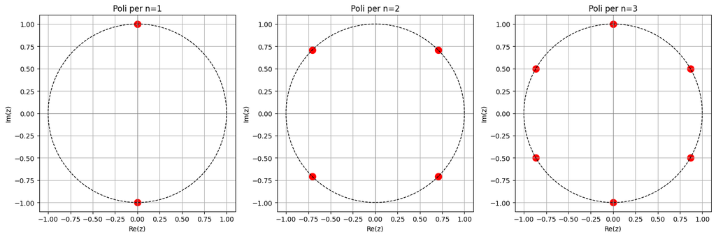

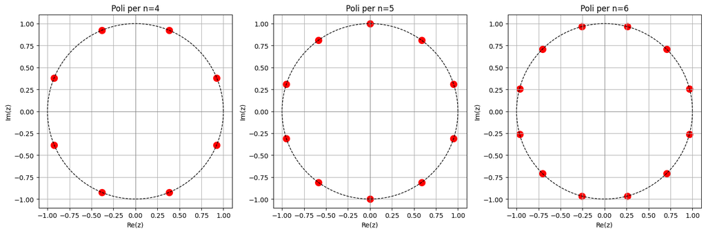

```python
import numpy as np
import matplotlib.pyplot as plt

def compute_poles(n):
    """
    Calcola i poli della funzione 1/(1+z^(2n))
    come radici del polinomio 1 + z^(2n).
    """
    coeffs = [0] * (2*n + 1)
    coeffs[0] = 1     # coefficiente di z^(2n)
    coeffs[-1] = 1    # termine costante
    return np.roots(coeffs)

# ----------------------------------------
# 3 subplot affiancati per n = 1, 2, 3
# ----------------------------------------
fig, axes = plt.subplots(1, 3, figsize=(15, 5))

n_values = [1, 2, 3]

for ax, n in zip(axes, n_values):
    poles = compute_poles(n)

    ax.scatter(poles.real, poles.imag, s=100, color="red", label=f"Poli n={n}")

    # Cerchio unitario
    theta = np.linspace(0, 2*np.pi, 400)
    ax.plot(np.cos(theta), np.sin(theta), 'k--', linewidth=1)

    # Migliorie estetiche
    ax.axhline(0, color='gray', linewidth=0.7)
    ax.axvline(0, color='gray', linewidth=0.7)
    ax.set_aspect('equal', 'box')
    ax.set_title(f"Poli per n={n}")
    ax.set_xlabel("Re(z)")
    ax.set_ylabel("Im(z)")
    ax.grid(True)

plt.tight_layout()
plt.show()

##%%%%%

# ----------------------------------------
# 3 subplot affiancati per n = 4,5,6
# ----------------------------------------
fig, axes = plt.subplots(1, 3, figsize=(15, 5))

n_values = [4,5,6]

for ax, n in zip(axes, n_values):
    poles = compute_poles(n)

    ax.scatter(poles.real, poles.imag, s=100, color="red", label=f"Poli n={n}")

    ax.plot(np.cos(theta), np.sin(theta), 'k--', linewidth=1)

    # Migliorie estetiche
    ax.axhline(0, color='gray', linewidth=0.7)
    ax.axvline(0, color='gray', linewidth=0.7)
    ax.set_aspect('equal', 'box')
    ax.set_title(f"Poli per n={n}")
    ax.set_xlabel("Re(z)")
    ax.set_ylabel("Im(z)")
    ax.grid(True)

plt.tight_layout()
plt.show()
```

## Esercizio 5.3

Calcolare l’integrale $$ I = \int_{-\infty}^{+\infty} \frac{\sin^2(x)}{x^2}\,dx. $$

## 1. Scrittura del seno in forma esponenziale

Usiamo $$ \sin x = \frac{e^{ix} - e^{-ix}}{2i}, \qquad \sin^2 x = \frac{1}{2} - \frac{1}{4}e^{2ix} - \frac{1}{4}e^{-2ix}. $$

Separare i termini è scomodo (l’integrale di (1/x^2) diverge).  
Conviene introdurre una funzione complessa più maneggevole.

## 2. Funzione complessa utile

Definiamo $$ f(z) = \frac{1 - e^{2iz}}{z^2}. $$

Osserviamo che $$ \Re f(x) = \frac{1 - \cos(2x)}{x^2} = \frac{\sin^2 x}{x^2}\cdot 2. $$

Quindi $$ I = \frac{1}{2}\int_{-\infty}^{+\infty} \Re f(x)\,dx = \frac{1}{2} \Re\!\left( \int_{-\infty}^{+\infty} f(x)\,dx \right). $$

## 3. Sviluppo di Laurent e residuo in (z=0)

Usiamo la serie: $$ e^{2iz} = 1 + 2iz - 2z^2 + O(z^3). $$

Quindi $$ 1 - e^{2iz} = -2iz + 2z^2 + O(z^3). $$

Dividendo per (z^2): $$ f(z) = -\frac{2i}{z} + 2 + O(z). $$

Dunque (f) ha un **polo semplice** in (z=0) con $$ \operatorname{Res}(f,0) = -2i. $$

## 4. Contorno con semicerchio grande e piccolo

Consideriamo un contorno che:

- segue l’asse reale da (-R) a (-\varepsilon),
- passa sopra (0) con un piccolo arco (C_\varepsilon),
- continua da (\varepsilon) a (R),
- chiude con un semicerchio grande nel semipiano superiore.

Per il teorema dei residui: $$ \int_{C_{R,\varepsilon}} f(z)\,dz = 2\pi i\,\operatorname{Res}(f,0) = 2\pi i\,(-2i) = 4\pi. $$

## 5. Contributo degli archi

### Semicerchio grande (C_R)

Nel semipiano superiore, $$ |e^{2iz}| = e^{-2\Im z} \le 1, $$ e si dimostra che $$ \lim_{R\to\infty} \int_{C_R} f(z)\,dz = 0. $$

### Archetto attorno a 0

Lo sviluppo locale dà $$ f(z) \sim -\frac{2i}{z}. $$

Integrando sul piccolo arco superiore: $$ \lim_{\varepsilon\to 0} \int_{C_\varepsilon} f(z)\,dz = 2\pi. $$

## 6. Valore principale sull’asse reale

La parte immaginaria dell’integrale è nulla (funzione dispari).
Dunque $$ \int_{-\infty}^{+\infty} \frac{1 - \cos(2x)}{x^2}\,dx = 2\pi. $$

Infine $$ I = \int_{-\infty}^{+\infty} \frac{\sin^2 x}{x^2}\,dx = \frac{1}{2} \cdot 2\pi = \pi. $$

### 5. Risultato finale

$$ \boxed{ \displaystyle \int_{-\infty}^{+\infty} \frac{\sin^2(x)}{x^2}\,dx = \pi. } $$

```python
import mpmath as mp

mp.mp.dps = 40  # cifre di precisione

f = lambda x: (mp.sin(x)**2) / (x**2) if x != 0 else 1  # definizione continua in x=0

I_num = mp.quad(f, [-mp.inf, 0, mp.inf])

print("Valore numerico ≈", I_num)
print("Valore teorico  =", mp.pi)
print("Differenza      =", I_num - mp.pi)
```

```
Valore numerico ≈ 3.142530627477218159117381943813638641706
Valore teorico  = 3.141592653589793238462643383279502884197
Differenza      = 0.000937973887424920654738560534135757508421
```

## Esercizio 5.4

Calcolare il seguente integrale: $$ I = \int_{-\infty}^{+\infty} \frac{\cos(2ax) - \cos(2bx)}{x^2}\,dx, \qquad a, b \in \mathbb{R}_+, \ a \ne b. $$

Per $a, b > 0$, $a \ne b$, vale $$ \boxed{ \displaystyle \int_{-\infty}^{+\infty} \frac{\cos(2ax) - \cos(2bx)}{x^2}\,dx = 2\pi (b - a) } $$

In particolare, se $b > a$, l’integrale è positivo; se $b < a$, è negativo.

```python
import mpmath as mp

mp.mp.dps = 40  # cifre di precisione

def I_num(a, b):
    f = lambda x: (mp.cos(2*a*x) - mp.cos(2*b*x)) / (x**2) if x != 0 else 0
    # L'integranda è pari, possiamo integrare su [0, +∞) e raddoppiare
    return 2 * mp.quad(f, [0, mp.inf])

def I_teo(a, b):
    return 2 * mp.pi * (b - a)

for (a, b) in [(1, 2), (2, 3), (0.5, 1.5)]:
    In = I_num(a, b)
    It = I_teo(a, b)
    print(f"a = {a}, b = {b}")
    print("  Integrale numerico  ≈", In)
    print("  Valore teorico      =", It)
    print("  Differenza          =", In - It)
    print()
```

```
a = 1, b = 2
  Integrale numerico  ≈ 6.283749363763432344008715613493142845197
  Valore teorico      = 6.283185307179586476925286766559005768394
  Differenza          = 0.0005640565838458670834288469341370768025659

a = 2, b = 3
  Integrale numerico  ≈ 6.287652618727695547039151152283649197495
  Valore teorico      = 6.283185307179586476925286766559005768394
  Differenza          = 0.004467311548109070113864385724643429100412

a = 0.5, b = 1.5
  Integrale numerico  ≈ 6.280502526260911063753073448107826080013
  Valore teorico      = 6.283185307179586476925286766559005768394
  Differenza          = -0.002682780918675413172213318451179688380934
```